# Project 1: Exploratory Analysis of Spotify’s Top 50 Tracks of 2023

2024-03-15

## Loading in our data

The following code was used to load in our data and to split genres and create a separate row for each genre while preserving song and artist information

df<- read.csv(“top_50_2023.csv, sep=”,“, header=TRUE)

df <- df %>% mutate(genres = str_split(genres, “,”)) %>% unnest(genres)

df %>% select(artist_name,genres)

## Cleaning up our data

We cleaned our data further by organizing our genre column in the dataset with the code below. We also were able to arrange our popularity column in descending order and select columns for analysis such as popularity, genres, track names, and artist names.

class(df$is_explicit)

unique(df$is_explicit)

df is_explicit<- as.factor(df$is_explicit)

class(df$is_explicit)

levels(df$is_explicit)

df %>% select(artist_name,track_name,popularity,genres) df <- arrange(df, desc(popularity))

## Finding the most common genres for the tracks

In order to find the most common genres for all the tracks in the dataset it was necessary to count the tracks of each genre, sort them by frequency, then display the top 5 tracks, and create a data frame for our plot on the next slide. This is the code below:

genre_counts <- table(unlist(df$genres))

sorted_genres <- sort(genre_counts, decreasing = TRUE) N <- 5

top_genres <- head(sorted_genres, N)

genre_data <- data.frame(genre = names(top_genres), frequency = as.numeric(top_genres))

top_genres <- head(genre_counts, 10)

## What are the most common genres among the top tracks?

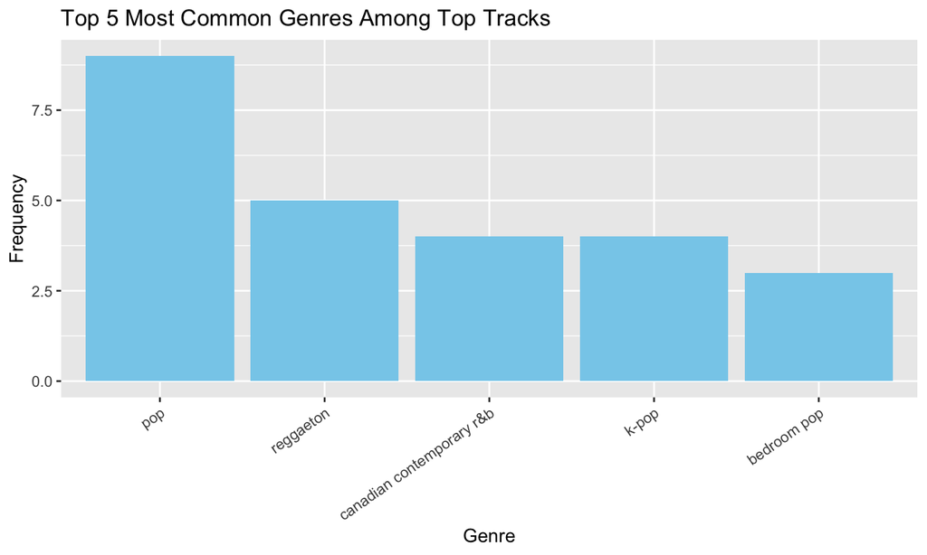

```
##                       genres n
## 1                        pop 9
## 2                  reggaeton 5
## 3  canadian contemporary r&b 4
## 4                      k-pop 4
## 5                bedroom pop 3
## 6                    corrido 3
## 7      singer-songwriter pop 2
## 8          argentine hip hop 2
## 9              colombian pop 2
## 10                 reggaeton 1
```

```
##                  danceability      valence      energy    loudness acousticness
## danceability       1.00000000  0.525479001  0.23252789  0.25529997  -0.21553662
## valence            0.52547900  1.000000000  0.37666681  0.12073312  -0.06602598
## energy             0.23252789  0.376666812  1.00000000  0.65634275  -0.36113127
## loudness           0.25529997  0.120733122  0.65634275  1.00000000  -0.25261293
## acousticness      -0.21553662 -0.066025976 -0.36113127 -0.25261293   1.00000000
## instrumentalness  -0.07283305 -0.263328832  0.15954540  0.17861957  -0.04581003
## liveness          -0.20249659 -0.108042532  0.02637286 -0.13431443   0.00177927
## speechiness        0.33239089 -0.005241012 -0.21800696  0.09134069  -0.14651755
## tempo             -0.07283901  0.125452388  0.13242725  0.11727058   0.05959618
## duration_ms       -0.06482851 -0.330536497 -0.19769930  0.16479419  -0.02683308
## time_signature     0.01252882 -0.144077055 -0.08735310 -0.06601346  -0.27121863
## popularity        -0.15737185 -0.008203636 -0.05739763  0.01996697  -0.16201631
##                  instrumentalness    liveness  speechiness        tempo
## danceability          -0.07283305 -0.20249659  0.332390886 -0.072839009
## valence               -0.26332883 -0.10804253 -0.005241012  0.125452388
## energy                 0.15954540  0.02637286 -0.218006961  0.132427245
## loudness               0.17861957 -0.13431443  0.091340690  0.117270584
## acousticness          -0.04581003  0.00177927 -0.146517546  0.059596176
## instrumentalness       1.00000000 -0.03769426 -0.092468233  0.012058686
## liveness              -0.03769426  1.00000000 -0.253529920 -0.075386957
## speechiness           -0.09246823 -0.25352992  1.000000000  0.192251977
## tempo                  0.01205869 -0.07538696  0.192251977  1.000000000
## duration_ms            0.09538389 -0.29689832  0.263154582 -0.143338323
## time_signature        -0.04277509 -0.09246260  0.149505536  0.005251868
## popularity            -0.13125730 -0.11673491  0.140163766  0.097114931
##                  duration_ms time_signature   popularity
## danceability     -0.06482851    0.012528821 -0.157371855
## valence          -0.33053650   -0.144077055 -0.008203636
## energy           -0.19769930   -0.087353102 -0.057397629
## loudness          0.16479419   -0.066013456  0.019966968
## acousticness     -0.02683308   -0.271218629 -0.162016311
## instrumentalness  0.09538389   -0.042775094 -0.131257299
## liveness         -0.29689832   -0.092462598 -0.116734911
## speechiness       0.26315458    0.149505536  0.140163766
## tempo            -0.14333832    0.005251868  0.097114931
## duration_ms       1.00000000    0.189976090 -0.112414445
## time_signature    0.18997609    1.000000000  0.218950244
## popularity       -0.11241445    0.218950244  1.000000000
```

## Heatmap of correlation between track attributes and popularity.

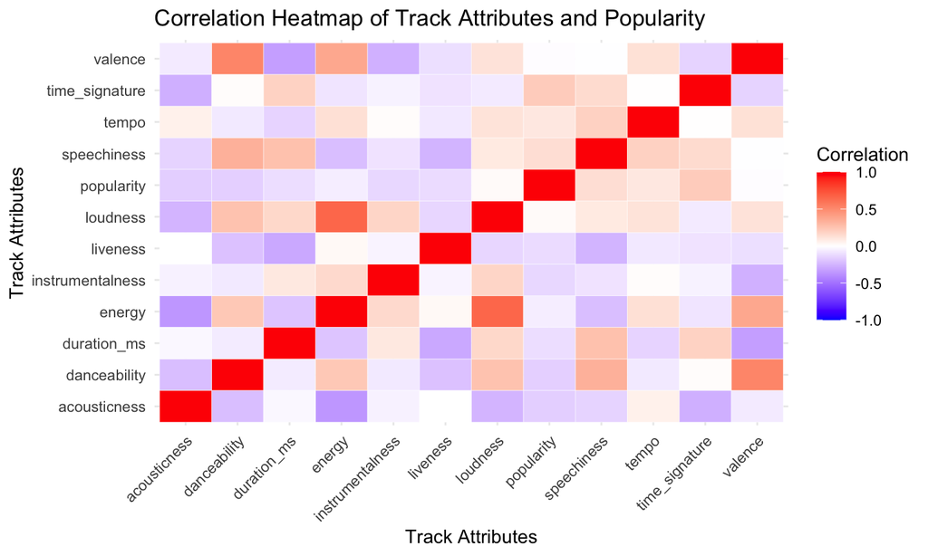

## How we set up a prediction model for track popularity

To create a prediction model for track popularity, we defined possible predictors and its response variable being popularity as stated before. We then used an if else statement to check if popularity was numeric, then we were ultimately able to make predictions on the test data given. This is the code below:

predictors <- c(“danceability”, “valence”, “energy”, “loudness”, “acousticness”, “instrumentalness”, “liveness”, “speechiness”, “tempo”, “duration_ms”, “time_signature”) response_var <- “popularity”

## How we set up a prediction model for track popularity cont.

We calculated RMSE for our prediction model and to do so we converted the response variable, trained a random forest model, and made predictions to ultimately calculate the RMSE.

The formula to calculate RMSE(Root Mean Squared Error) is:

\[ RMSE = \sqrt{\frac{\sum_{i=1}^{n} (y_i - \hat{y}_i)^2}{n}} \]

## Predicting Track Popularity

Here are the RMSE values we obtained based on our prediction model:

```
## [1] "Random Forest RMSE: 9.46513510791638"
## [1] "Feature Importance:"
##                     %IncMSE IncNodePurity
## danceability      0.7285468     132.15223
## valence          -0.7147758      82.81624
## energy           -1.2894757      64.19214
## loudness          1.5135163      77.07723
## acousticness     -0.9358643      63.70563
## instrumentalness  0.6624328      48.40721
## liveness         -0.4491487      79.79069
## speechiness      -1.0495332      77.08184
## tempo            -1.8434936      82.78818
## duration_ms       1.1279341     119.66727
## time_signature    1.8943356      14.80190
```

## Conclusion

Through our analysis, we gained valuable insights into the factors influencing track popularity within Spotify’s “Top Tracks of 2023” playlist. Here are the key findings and conclusions:

Genre Influence: While we did not explicitly analyze genre influence in predicting track popularity, it’s worth noting that genre can play a crucial role in shaping listener preferences. Future studies could explore the relationship between specific genres and track popularity within the dataset.

## Conclusion cont.

Recommendations: Based on our findings,industry professionals can leverage the insights gained to inform their decision-making processes. By understanding the features that contribute most significantly to track popularity, artists can tailor their music production strategies to align with listener preferences